# Stat302_Lab2

2023-09-28

Use Data11_bac.xlsx data set in this lab. Read the data from excel in the following chunk.Then, explore how many observations and how many variables in it. Also use appropriate plots or summaries to present the variables

```r
Data11_bac <- read_excel("C:/Users/cmpas/Downloads/Data11_bac .xlsx")

head(Data11_bac)
```

```
## # A tibble: 6 × 7
##   id_osu gender weight beers   bac presobr postsobr
##    <dbl> <chr>   <dbl> <dbl> <dbl>   <dbl>    <dbl>
## 1      1 female    132     5 0.1     10        6
## 2      2 female    128     2 0.03     9.5      9.25
## 3      3 female    110     9 0.19     9.75     4.75
## 4      4 male      192     8 0.12    10        7.5
## 5      5 male      172     3 0.04    10        9.75
## 6      6 female    250     7 0.095    9.5      6.5
```

```r
summary(Data11_bac)
```

```
##      id_osu         gender              weight          beers
##  Min.   : 1.00   Length:16          Min.   :110.0   Min.   :1.000
##  1st Qu.: 4.75   Class :character   1st Qu.:129.5   1st Qu.:3.000
##  Median : 8.50   Mode  :character   Median :170.0   Median :5.000
##  Mean   : 8.50                      Mean   :171.6   Mean   :4.812
##  3rd Qu.:12.25                      3rd Qu.:179.2   3rd Qu.:6.250
##  Max.   :16.00                      Max.   :275.0   Max.   :9.000
##       bac             presobr          postsobr
##  Min.   :0.01000   Min.   : 9.500   Min.   :4.750
##  1st Qu.:0.04750   1st Qu.: 9.500   1st Qu.:6.875
##  Median :0.07000   Median : 9.750   Median :8.000
##  Mean   :0.07375   Mean   : 9.719   Mean   :7.797
##  3rd Qu.:0.09625   3rd Qu.:10.000   3rd Qu.:8.812
##  Max.   :0.19000   Max.   :10.000   Max.   :9.750
```

```r
str(Data11_bac)
```

```
## tibble [16 × 7] (S3: tbl_df/tbl/data.frame)
##  $ id_osu  : num [1:16] 1 2 3 4 5 6 7 8 9 10 ...
##  $ gender  : chr [1:16] "female" "female" "female" "male" ...
##  $ weight  : num [1:16] 132 128 110 192 172 250 125 175 175 275 ...
##  $ beers   : num [1:16] 5 2 9 8 3 7 3 5 3 5 ...
##  $ bac     : num [1:16] 0.1 0.03 0.19 0.12 0.04 0.095 0.07 0.06 0.02 0.05 ...
##  $ presobr : num [1:16] 10 9.5 9.75 10 10 9.5 9.5 9.75 9.5 9.75 ...
##  $ postsobr: num [1:16] 6 9.25 4.75 7.5 9.75 6.5 7 8.75 6 8.5 ...
```

### Explarotory Data Analysis

Look at the scatter plot of BAC versus number of beers consumed. Does the relationship look linear.

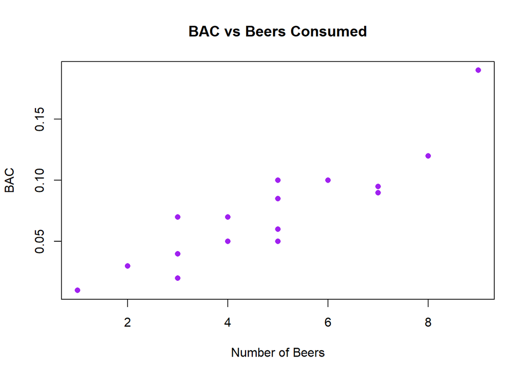

```r
BAC_vs_Beers <- plot(Data11_bac$beers, Data11_bac$bac, main = "BAC vs Beers Consumed", xlab = "Number of Beers", ylab = "BAC", pch = 16, col = "purple")
```

```r
paste("The relationship between BAC and beers consumed looks linear based of the scatter plot.")
```

```
## [1] "The relationship between BAC and beers consumed looks linear based of the scatter plot."
```

Calculate the correlation coefficient, r. What is the strength and the direction of the relationship based on r?

```r
correlation_coefficient <- cor(Data11_bac$beers, Data11_bac$bac)

print(correlation_coefficient)
```

```
## [1] 0.8943381
```

```r
paste("The correlation coeffecient of .894 indicates a strong positive linear relationship. (Since correlation coeffecient is close to 1)")
```

```
## [1] "The correlation coeffecient of .894 indicates a strong positive linear relationship. (Since correlation coeffecient is close to 1)"
```